# QBUS2820 - Predictive Analytics

# Tutorial 2 - Part A

## Data Handling with Pandas

https://pandas.pydata.org/pandas-docs/stable/

Pandas is a library for data manipulation. The key feature of Pandas is that the data structures it uses (a Dataframe) can hold multiple different data types. For example it can create an array with integers, strings and floating point numbers all at once. You could consider this capability as similar to an excel spreadsheet. Whereas you cannot mix and match data types in Python Lists or Numpy Arrays.

Pandas is already installed and available in Anaconda/Spyder. To begin using it we first import it as follows

```python
import pandas as pd
```

Download the DirectMarketing.xlsx file from Blackboard and place it in the same folder as your Python file or Jupyter Notebook.

The data set “DirectMarketing.csv” comes from the book *Business Analytics for Managers* by Wolfgang Jank. It contains information on 1000 customers in a customer database for the comany Direct Marketing (DM).

We can load the file into Python and convert it to a Dataframe by

```python
marketing = pd.read_excel('DirectMarketing.xlsx')
```

We can check the first 5 rows of the marketing Dataframe by using its head function.

Here is the docs for the head function https://pandas.pydata.org/pandas-docs/stable/generated/pandas.DataFrame.head.html

```python
marketing.head()
```

|  | Age | Gender | OwnHome | Married | Location | Salary | Children | History | Catalogs | AmountSpent |
| --- | --- | --- | --- | --- | --- | --- | --- | --- | --- | --- |
| 0 | Old | Female | Own | Single | Far | 47500 | 0 | High | 6 | 755 |
| 1 | Middle | Male | Rent | Single | Close | 63600 | 0 | High | 6 | 1318 |
| 2 | Young | Female | Rent | Single | Close | 13500 | 0 | Low | 18 | 296 |
| 3 | Middle | Male | Own | Married | Close | 85600 | 1 | High | 18 | 2436 |
| 4 | Middle | Female | Own | Single | Close | 68400 | 0 | High | 12 | 1304 |

To see the full information about a dataframe including number of entries and datatypes use the info() function

```python
marketing.info()
```

```
<class 'pandas.core.frame.DataFrame'>
RangeIndex: 1000 entries, 0 to 999
Data columns (total 10 columns):
Age            1000 non-null object
Gender         1000 non-null object
OwnHome        1000 non-null object
Married        1000 non-null object
Location       1000 non-null object
Salary         1000 non-null int64
Children       1000 non-null int64
History        697 non-null object
Catalogs       1000 non-null int64
AmountSpent    1000 non-null int64
dtypes: int64(4), object(6)
memory usage: 78.2+ KB
```

```python
marketing.describe()
```

|  | Salary | Children | Catalogs | AmountSpent |
| --- | --- | --- | --- | --- |
| count | 1000.000000 | 1000.00000 | 1000.000000 | 1000.000000 |
| mean | 56103.900000 | 0.93400 | 14.682000 | 1216.770000 |
| std | 30616.314826 | 1.05107 | 6.622895 | 961.068613 |
| min | 10100.000000 | 0.00000 | 6.000000 | 38.000000 |
| 25% | 29975.000000 | 0.00000 | 6.000000 | 488.250000 |
| 50% | 53700.000000 | 1.00000 | 12.000000 | 962.000000 |
| 75% | 77025.000000 | 2.00000 | 18.000000 | 1688.500000 |
| max | 168800.000000 | 3.00000 | 24.000000 | 6217.000000 |

### Pandas Series

A Series is a column of a Pandas DataFrame.

```python
catalogs = marketing['Catalogs']

catalogs.head()
```

```
0     6
1     6
2    18
3    18
4    12
Name: Catalogs, dtype: int64
```

```python
catalogs = marketing.iloc[:, 8]

catalogs.head()
```

```
0     6
1     6
2    18
3    18
4    12
Name: Catalogs, dtype: int64
```

To find the number of unique values for a categorical column you can use nunique()

```python
catalogs.nunique()
```

```
4
```

To see the unique values and the number of entries for each value you can use value_counts()

```python
marketing['Catalogs'].value_counts()
```

```
12    282
6     252
24    233
18    233
Name: Catalogs, dtype: int64
```

## Pyplot

https://matplotlib.org/api/pyplot_api.html

Pyplot is a library for data plotting. Pyplot follows many of the conventions of MATLAB's plotting functions. It provides a very simple interface to plotting for common tasks. Pyplot is a sub-library of matplotlib.

To begin using it we first import it as follows

```python
import matplotlib.pyplot as plt
```

Pyplot requires a figure to draw each plot upon. A Figure can contain a single plot or you can subdivide it into many plots. You can think of a figure as a "blank canvas" to draw on.

By default Pyplot will draw on the las figure you created.

Creating a new figure is simple

```python
my_figure = plt.figure()
```

### Line Plot

Lets create a simple line plot from some randomly generated data.

The plot function makes a line by taking a set of (x,y) points and joining them together.

The plot function takes one or two input arrays. If you provide one input it assumes that the input is for the y-axis and then evenly spaces each point on the x-axis. If you provide two inputs it places each point in the exact coordinates that you have specified.

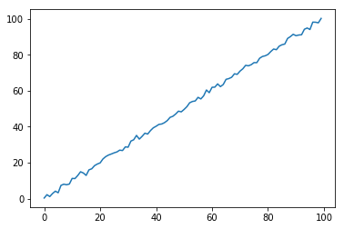

```python
import numpy as np

x = np.arange(100)
y = np.linspace(0, 100, 100) + np.random.randn(100)

plt.plot(x, y, label="My Variable")

my_figure
```

### Histogram

Let's create a simple histogram of a variable from the direct marketing dataset.

The variable of interest is the AmountSpent of each person.

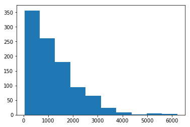

```python
my_figure2 = plt.figure()

amount_spent = marketing['AmountSpent']

n, bins, patches = plt.hist(amount_spent)

my_figure2
```

This plot is a little hard to read so let's make some adjustments so that it is more presentable. You can see the full parameters for the hist() function here https://matplotlib.org/api/pyplot_api.html#matplotlib.pyplot.hist

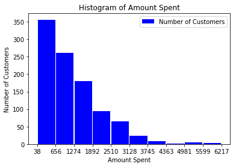

```python
my_figure3 = plt.figure()

n, bins, patches = plt.hist(amount_spent, rwidth = 0.95, bins=10, align = "mid", label = "Number of Customers", color = [0, 0, 1, 1])

# Colour is specified as Red, Green, Blue, Alpha

plt.xticks(bins)
plt.xlabel("Amount Spent")
plt.ylabel("Number of Customers")
plt.title("Histogram of Amount Spent")
plt.legend()

my_figure3
```